# Market Basket Analysis Report

## Executive summary:

From what we observed, obtaining the company Electroindex is a good idea for Blackwell. Both companies are complementary and would benefit for the high amount of sales from respective diferent products. Accesories are high on Blackwell’s side while Computer are high in Electroindex, doing cross-selling between the companies would benefit both, therefore, we recommend to specialize each company in what they sell best and merge.

## Introduction:

To gather all the neccessery insights about Electroindex’s business activity, we have used their online transactions data and a file containing all the electronics that they currently sell. Due to their lack of funding, Electronidex is only able to pull data on the items that customers purchased per their transactions, meaning that we cannot identify whether the same customer made multiple transactions during this time period.

## Insights and findings:

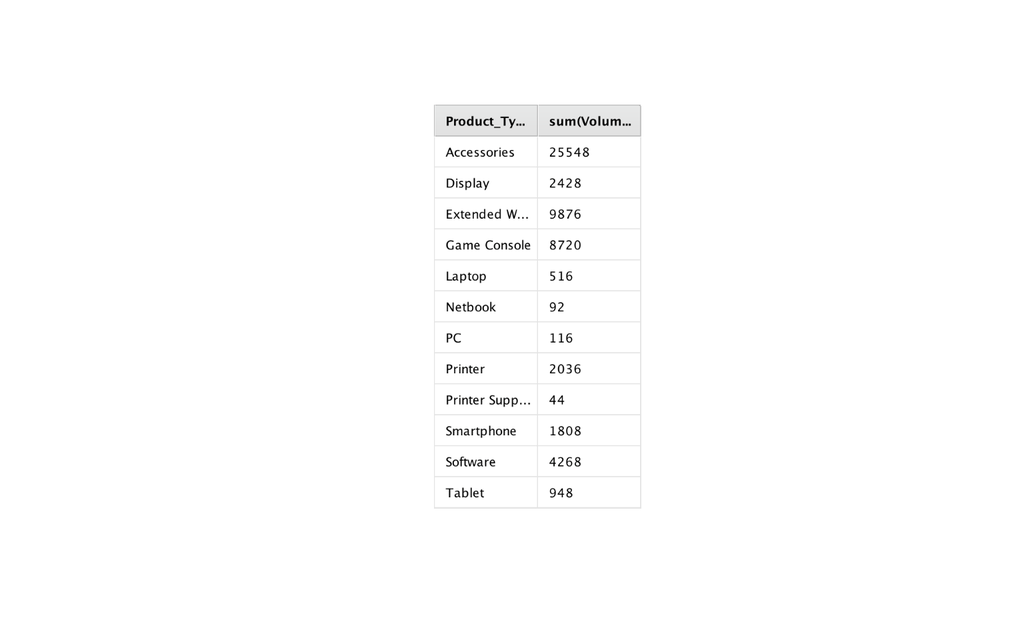

We also know that products that have the highest predicted profitability for Blackwell are Tablets and PCs, shown on the ranked table below:

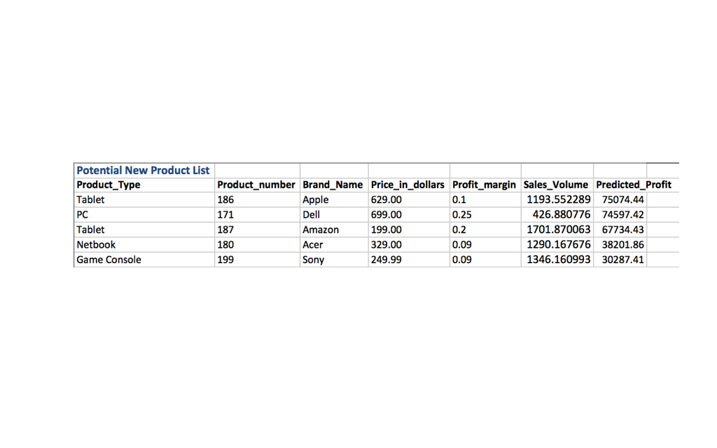

Using product association insights and the above information, we can conclude that Blackwell can gain profits in the following way if it decides to buy Electroindex:

```
## Number of transactions
## [1] 9835
##      items
## [1]  Acer Aspire + Belkin Mouse Pad + Brother Printer Toner + VGA Monitor Cable
## [2]  Apple Wireless Keyboard + Dell Desktop + Lenovo Desktop Computer
## [3]  iMac
## [4]  Acer Desktop + Intel Desktop + Lenovo Desktop Computer + XIBERIA Gaming Headset
## [5]  ASUS Desktop + Epson Black Ink + HP Laptop + iMac
## [6]  ASUS Monitor + Gaming Mouse Professional + iMac + Lenovo Desktop Computer + Mackie CR Speakers
## [7]  CYBERPOWER Gamer Desktop
## [8]  Apple MacBook Air + Bose Companion Speakers + CYBERPOWER Gamer Desktop + HP Laptop + Large Mouse Pad
## [9]  Logitech Keyboard
## [10] Generic Black 3-Button + iMac
## Number of transactions per item: /n
## [1] "1 Item --> 2163"
## [1] "2 Item --> 1647"
## [1] "3 Item --> 1294"
## [1] "4 Item --> 1021"
## [1] "5 Item --> 856"
## [1] "6 Item --> 646"
```

While doing market basket analysis, we have discovered some strong associations between Electroindex’s products. In particular, a lot of customers who shop at Electroindex will purchase “bundles” of products, mainly as a combination of desktop/laptop and accessories. We have also found out that Electroindex’s most sold products are desktops and laptops, which you can see on the graph below:

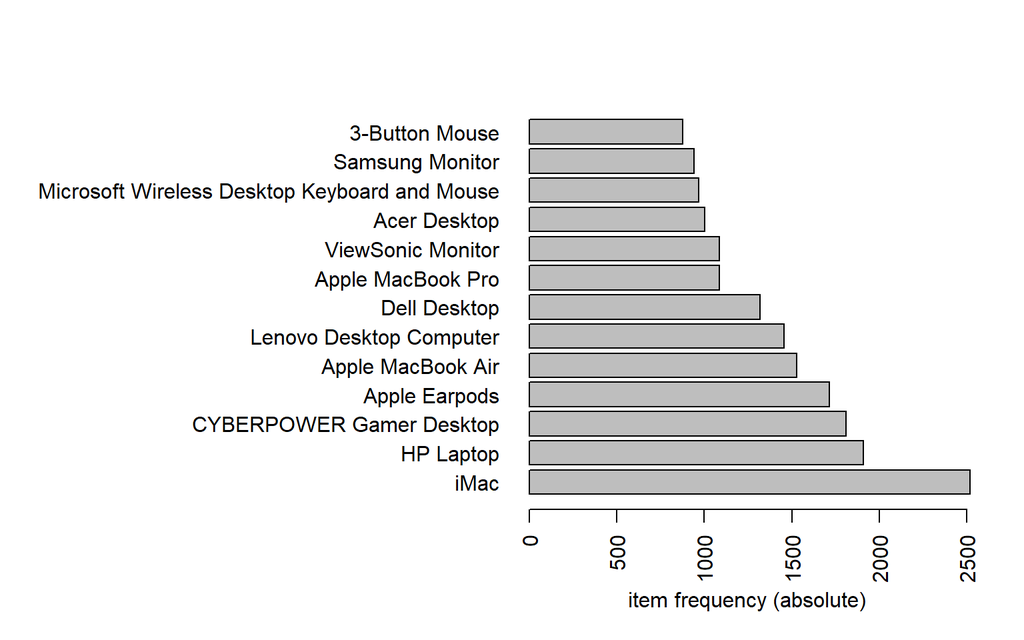

```
##
## Rules Sorted by lift
##     lhs
## [1] Dell KM117 Wireless Keyboard & Mouse + iPhone Charger Cable        =>
## [2] HP Monitor + iMac + Koss Home Headphones                           =>
## [3] 3-Button Mouse + Acer Desktop + ASUS Monitor                       =>
## [4] Acer Aspire + Dell Desktop + iMac + ViewSonic Monitor              =>
## [5] Epson Printer + iMac + Lenovo Desktop Computer + ViewSonic Monitor =>
##     rhs                     support     confidence lift     count
## [1] Apple MacBook Air       0.002033554 0.9523810  6.122004 20
## [2] Lenovo Desktop Computer 0.001525165 0.8823529  5.960124 15
## [3] HP Laptop               0.001525165 0.9375000  4.829917 15
## [4] HP Laptop               0.003762074 0.9024390  4.649286 37
## [5] HP Laptop               0.001728521 0.8947368  4.609605 17
##
```

[output cut: 27 more lines]

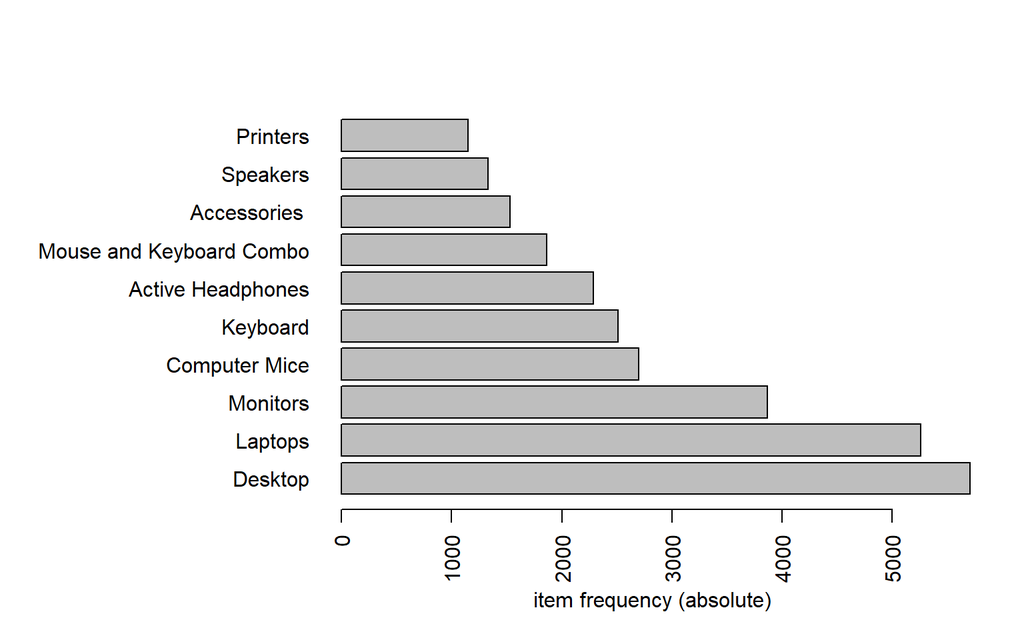

```
## [1] "48.56% of transactions are done by Costumers"
## [1] "51.44% of transactions are done by Companies"
## [1] "6.78% of transactions are done by Gamers"
```

## Conclusion:

Using association insights and comparing which types of products both Blackwell and Electroindex sell, we can conclude that if Blackwell buys Electroindex, it will benefit the most from selling Electroindex’s most sold items such as PCs/Laptops/Desktops bundled with Blackwell’s accessories supply. Unless Electroindex mainly deals with businesses, meaning that they have a much larger supply of electronics which might not be necessery for a company like Blackwell, who mainly deal with non business customers, the acquisition of Electroindex will bring more profit in the future. Further discussion is required in order to understand Blackwell’s objectives more clearly, which will make it easier to decide wether Blackwell should buy Electroindex.

Ivan Sokolenko, Alejo Gonzalez Mata, Joan Figueras

12/04/2019